# P8106 - HW1

Ravi Brenner

```r
library(glmnet)
library(caret)
library(tidymodels)
library(pls)
library(readr)
```

## Data and problem

Load data

```r
training <- read_csv("housing_training.csv")
testing <- read_csv("housing_test.csv")
```

Very brief exploration of the training data

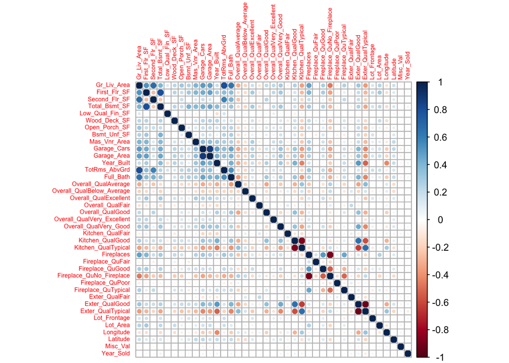

```r
x <- model.matrix(Sale_Price ~ ., training)[,-1]
corrplot::corrplot(cor(x),
                   method = "circle", type = "full", tl.cex = 0.5)
```

## a. Lasso model

1. Fit a lasso model on the training data. Report the selected tuning parameter and the test error. When the 1SE rule is applied, how many predictors are included in the model?

Fit model

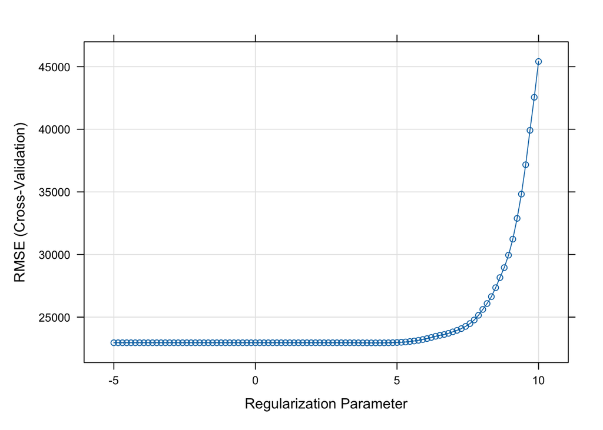

```r
ctrl1 <- trainControl(method = "cv", number = 10, selectionFunction = "best")

set.seed(2025)
lasso.fit <- train(Sale_Price ~ .,
                   data = training,
                   method = "glmnet",
                   tuneGrid = expand.grid(alpha = 1,
                                          lambda = exp(seq(10, -5, length = 100))),
                   trControl = ctrl1)

plot(lasso.fit, xTrans = log)
```

Best tuning parameter

```r
best_lambda <- lasso.fit$bestTune$lambda
best_lambda
```

```
## [1] 69.57632
```

test error

```r
lasso.pred <- predict(lasso.fit, newdata = testing)
mean((lasso.pred - testing[, "Sale_Price"])^2 |> pull()) #MSE
```

```
## [1] 439568493
```

```r
mean((lasso.pred - testing[, "Sale_Price"])^2 |> pull()) |> sqrt() #RMSE
```

```
## [1] 20965.89
```

How many coefficients in 1se model?

First, find 1se lambda value

```r
# fit 1se version
ctrl2 <- trainControl(method = "cv", number = 10, selectionFunction = "oneSE")
set.seed(2025)
lasso.1se <- train(Sale_Price ~ .,
                   data = training,
                   method = "glmnet",
                   tuneGrid = expand.grid(alpha = 1,
                                          lambda = exp(seq(10, -5, length = 100))),
                   trControl = ctrl2)

lambda_1se <- lasso.1se$bestTune |> pull(lambda)
```

We can also calculate this value manually. The model output `results` gives the RMSE and RMSESD. To convert the SD to SE, we have to divide by the square root (because it is *root* mean square error) of the square root of the fold size (the standard way to calculate SE from SD). In this case the fold size is 144, so we divide by the square root of 12.

```r
rmse_1se <- lasso.fit$results |>
  filter(lambda == best_lambda) |>
  mutate(RMSESE = RMSESD / sqrt(12), # why sqrt(12)? in MSE formula is 1/sqrt(fold size)*SD. for RMSE do sqrt of that which is 12 for 1440/10
         RMSE_1SE = RMSE + RMSESE) |>
  pull(RMSE_1SE)

lasso.fit$results |>
  filter(RMSE > 23500,
         RMSE < 23600)
```

| alpha | lambda | RMSE | Rsquared | MAE | RMSESD | RsquaredSD | MAESD |
| --- | --- | --- | --- | --- | --- | --- | --- |
| 1 | 675.2963 | 23542.89 | 0.8973281 | 16778.67 | 2281.745 | 0.01771693 | 1527.013 |

model with 1se lambda value

```r
coef(lasso.fit$finalModel, lambda_1se)
```

```
## 40 x 1 sparse Matrix of class "dgCMatrix"
##                                       s1
## (Intercept)                -2.916836e+06
## Gr_Liv_Area                 5.794761e+01
## First_Flr_SF                1.006061e+00
## Second_Flr_SF               .
## Total_Bsmt_SF               3.674362e+01
## Low_Qual_Fin_SF            -2.879529e+01
## Wood_Deck_SF                8.702628e+00
## Open_Porch_SF               9.147142e+00
## Bsmt_Unf_SF                -2.005078e+01
## Mas_Vnr_Area                1.402927e+01
## Garage_Cars                 3.115356e+03
## Garage_Area                 1.082411e+01
## Year_Built                  3.110661e+02
## TotRms_AbvGrd              -1.695581e+03
## Full_Bath                   .
## Overall_QualAverage        -3.311972e+03
## Overall_QualBelow_Average  -9.646160e+03
## Overall_QualExcellent       9.132387e+04
## Overall_QualFair           -7.183517e+03
## Overall_QualGood            1.031218e+04
## Overall_QualVery_Excellent  1.614854e+05
## Overall_QualVery_Good       3.677171e+04
## Kitchen_QualFair           -5.938606e+03
## Kitchen_QualGood            .
## Kitchen_QualTypical        -9.520503e+03
## Fireplaces                  6.652772e+03
## Fireplace_QuFair           -1.054475e+02
## Fireplace_QuGood            4.425741e+03
## Fireplace_QuNo_Fireplace    .
## Fireplace_QuPoor            .
## Fireplace_QuTypical        -9.329979e+02
## Exter_QualFair             -1.522564e+04
## Exter_QualGood              .
## Exter_QualTypical          -4.883074e+03
## Lot_Frontage                7.603302e+01
## Lot_Area                    5.739267e-01
## Longitude                  -1.428573e+04
## Latitude                    2.408926e+04
## Misc_Val                    .
## Year_Sold                   .
```

```r
# Number of predictors
coef(lasso.fit$finalModel, lambda_1se) |> as.matrix() |> as.data.frame() |> filter(s1 > 0) |> nrow()
```

```
## [1] 18
```

## b. Elastic net

2. Fit an elastic net model on the training data. Report the selected tuning parameters and the test error. Is it possible to apply the 1SE rule to select the tuning parameters for elastic net? If the 1SE rule is applicable, implement it to select the tuning parameters. If not, explain why.

Fit Elastic net model

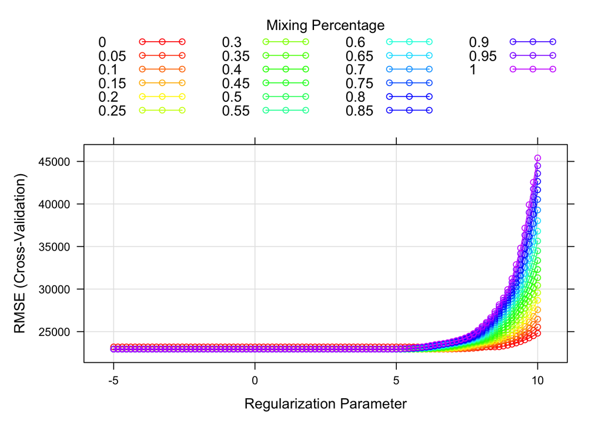

```r
set.seed(2025)
enet.fit <- train(Sale_Price ~ .,
                  data = training,
                  method = "glmnet",
                  tuneGrid = expand.grid(alpha = seq(0, 1, length = 21),
                                         lambda = exp(seq(10, -5, length = 100))),
                  trControl = ctrl1)


myCol <- rainbow(25)
myPar <- list(superpose.symbol = list(col = myCol),
              superpose.line = list(col = myCol))

plot(enet.fit, par.settings = myPar, xTrans = log)
```

```r
# coefficients in the final model
coef(enet.fit$finalModel, s = enet.fit$bestTune$lambda)
```

```
## 40 x 1 sparse Matrix of class "dgCMatrix"
##                                       s1
## (Intercept)                -5.112158e+06
## Gr_Liv_Area                 3.877699e+01
## First_Flr_SF                2.670023e+01
## Second_Flr_SF               2.545573e+01
## Total_Bsmt_SF               3.494355e+01
## Low_Qual_Fin_SF            -1.586366e+01
## Wood_Deck_SF                1.232450e+01
## Open_Porch_SF               1.687896e+01
## Bsmt_Unf_SF                -2.072832e+01
## Mas_Vnr_Area                1.165193e+01
## Garage_Cars                 4.046992e+03
## Garage_Area                 8.889587e+00
## Year_Built                  3.192146e+02
## TotRms_AbvGrd              -3.441518e+03
## Full_Bath                  -3.694920e+03
## Overall_QualAverage        -5.116544e+03
## Overall_QualBelow_Average  -1.270853e+04
## Overall_QualExcellent       7.582058e+04
## Overall_QualFair           -1.147242e+04
## Overall_QualGood            1.198403e+04
## Overall_QualVery_Excellent  1.363756e+05
## Overall_QualVery_Good       3.765989e+04
## Kitchen_QualFair           -2.369556e+04
## Kitchen_QualGood           -1.611428e+04
## Kitchen_QualTypical        -2.416472e+04
## Fireplaces                  1.083070e+04
## Fireplace_QuFair           -7.857118e+03
## Fireplace_QuGood            1.490291e+02
## Fireplace_QuNo_Fireplace    1.823280e+03
## Fireplace_QuPoor           -5.803365e+03
## Fireplace_QuTypical        -6.962039e+03
## Exter_QualFair             -3.297575e+04
## Exter_QualGood             -1.457261e+04
## Exter_QualTypical          -1.916633e+04
## Lot_Frontage                1.001768e+02
## Lot_Area                    6.032398e-01
## Longitude                  -3.515129e+04
## Latitude                    5.776171e+04
## Misc_Val                    8.685961e-01
## Year_Sold                  -5.749899e+02
```

Best tuning parameters alpha and lambda

```r
enet.fit$bestTune
```

|  | alpha | lambda |
| --- | --- | --- |
| 176 | 0.05 | 580.3529 |

test error

```r
enet.pred <- predict(enet.fit, newdata = testing)
mean((enet.pred - testing[, "Sale_Price"])^2 |> pull()) #MSE
```

```
## [1] 438615743
```

```r
mean((enet.pred - testing[, "Sale_Price"])^2 |> pull()) |> sqrt() #RMSE
```

```
## [1] 20943.16
```

Mechanically speaking, it is possible to apply the 1SE rule to elastic net:

```r
# fit 1se version
ctrl2 <- trainControl(method = "cv", number = 10, selectionFunction = "oneSE")
set.seed(2025)
enet.1se <- train(Sale_Price ~ .,
                  data = training,
                  method = "glmnet",
                  tuneGrid = expand.grid(alpha = seq(0, 1, length = 21),
                                         lambda = exp(seq(10, -5, length = 100))),
                  trControl = ctrl2)

enet.1se$bestTune
```

|  | alpha | lambda |
| --- | --- | --- |
| 94 | 0 | 8874.25 |

```r
enet.fit$results |>
  filter(lambda == enet.fit$bestTune |> pull(lambda),
         alpha == enet.fit$bestTune |> pull(alpha)) |>
  mutate(RMSESE = RMSESD / sqrt(12), # why sqrt(12)? in MSE formula is 1/sqrt(fold size)*SD. for RMSE do sqrt of that which is 12 for 1440/10
         RMSE_1SE = RMSE + RMSESE) |>
  pull(RMSE_1SE)
```

```
## [1] 23531.45
```

```r
enet.fit$results |>
  filter(RMSE > 23500,
         RMSE < 23600)
```

| alpha | lambda | RMSE | Rsquared | MAE | RMSESD | RsquaredSD | MAESD |
| --- | --- | --- | --- | --- | --- | --- | --- |
| 0.00 | 8874.2499 | 23519.64 | 0.8984303 | 16761.08 | 2374.337 | 0.01694508 | 1441.975 |
| 0.10 | 4160.2620 | 23519.39 | 0.8980426 | 16711.68 | 2355.696 | 0.01724977 | 1501.709 |
| 0.20 | 2640.6698 | 23533.60 | 0.8977256 | 16719.61 | 2342.145 | 0.01741654 | 1522.439 |
| 0.25 | 2269.4045 | 23551.72 | 0.8975295 | 16734.28 | 2345.117 | 0.01748456 | 1530.335 |
| 0.30 | 1950.3372 | 23552.90 | 0.8974688 | 16740.23 | 2340.162 | 0.01753041 | 1532.095 |
| 0.35 | 1676.1293 | 23540.45 | 0.8975203 | 16738.65 | 2327.784 | 0.01754849 | 1530.642 |
| 0.40 | 1440.4737 | 23516.82 | 0.8976635 | 16730.12 | 2308.848 | 0.01753529 | 1525.858 |
| 0.45 | 1440.4737 | 23581.69 | 0.8971593 | 16769.62 | 2334.959 | 0.01765471 | 1540.065 |
| 0.50 | 1237.9501 | 23544.89 | 0.8974051 | 16756.52 | 2309.808 | 0.01762218 | 1531.465 |
| 0.55 | 1063.9003 | 23500.92 | 0.8977170 | 16736.79 | 2283.527 | 0.01757529 | 1521.637 |

[output cut: 13 more lines]

Although it is possible to select a 1SE lambda value using the available caret functions, I do not think this is the best idea for elastic net. It is very challenging to accurately apply the 1SE rule to the elastic net model, because there are multiple combinations of alpha and lambda that yield similar RMSE values which are close to the 1SE value. You could further refine the grid to create a more precise search for the exact 1SE value, but ultimately multiple combinations of alpha and lambda will remain as potential solutions. The new value of lambda that corresponds to the “1SE solution” also comes with a different alpha value, meaning you are then jumping onto a different curve to compare RMSE values, and thereby changing the meaning of the lambda value too. It is therefore hard to interpret which combination of values is best with this added flexibility. Thus I would not use the 1SE method with elastic net.

## c. Partial least squares

3. Fit a partial least squares model on the training data and report the test error. How many components are included in your model?

```r
set.seed(2025)

pls.fit <- train(Sale_Price ~ .,
                 data = training,
                 method = "pls",
                 tuneGrid = data.frame(ncomp = 1:(ncol(training)-1)),
                 trControl = ctrl1,
                 preProcess = c("center","scale"))

pred_pls <- predict(pls.fit, newdata = testing)
mean((testing$Sale_Price - pred_pls)^2) |> sqrt() #RMSE
```

```
## [1] 21243.27
```

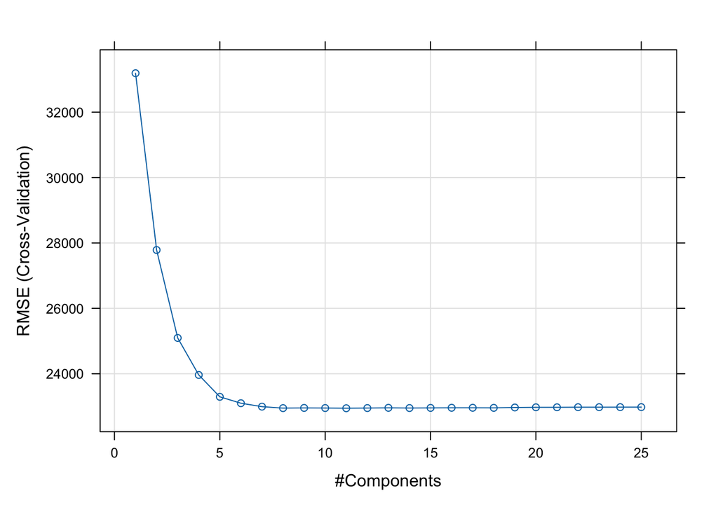

```r
plot(pls.fit)
```

```r
pls.fit$bestTune
```

|  | ncomp |
| --- | --- |
| 11 | 11 |

There are 11 components in the optimal PLS model.

## d. Model comparison

4. Choose the best model for predicting the response and explain your choice.

```r
resamp <- resamples(list(lasso = lasso.fit,
                         lasso_1se = lasso.1se,
                         enet = enet.fit,
                         pls = pls.fit))
summary(resamp)
```

```
##
## Call:
## summary.resamples(object = resamp)
##
## Models: lasso, lasso_1se, enet, pls
## Number of resamples: 10
##
## MAE
##               Min.  1st Qu.   Median     Mean  3rd Qu.     Max. NA's
## lasso     14741.86 15555.86 16284.84 16677.58 17493.56 19166.12    0
## lasso_1se 14996.43 15493.21 16421.93 16778.67 17939.52 19629.84    0
## enet      14789.53 15501.17 16268.01 16654.09 17494.45 19151.88    0
## pls       14848.76 15656.74 16411.28 16743.46 17517.21 19194.05    0
##
## RMSE
##               Min.  1st Qu.   Median     Mean  3rd Qu.     Max. NA's
## lasso     19793.26 21879.30 22650.75 22944.36 23782.53 27027.81    0
## lasso_1se 20825.73 21757.54 23517.66 23542.89 24701.04 28300.57    0
## enet      19827.17 21904.35 22614.81 22939.63 23774.73 27064.17    0
## pls       19837.01 21953.53 22716.43 22945.08 23772.46 26935.47    0
##
## Rsquared
##                Min.   1st Qu.    Median      Mean   3rd Qu.      Max. NA's
## lasso     0.8774739 0.8893619 0.9002486 0.9021463 0.9163527 0.9249577    0
## lasso_1se 0.8771573 0.8839686 0.8924394 0.8973281 0.9072272 0.9260259    0
## enet      0.8776374 0.8894404 0.9005349 0.9021885 0.9160495 0.9254490    0
## pls       0.8774820 0.8893300 0.8997448 0.9020588 0.9164506 0.9243377    0
```

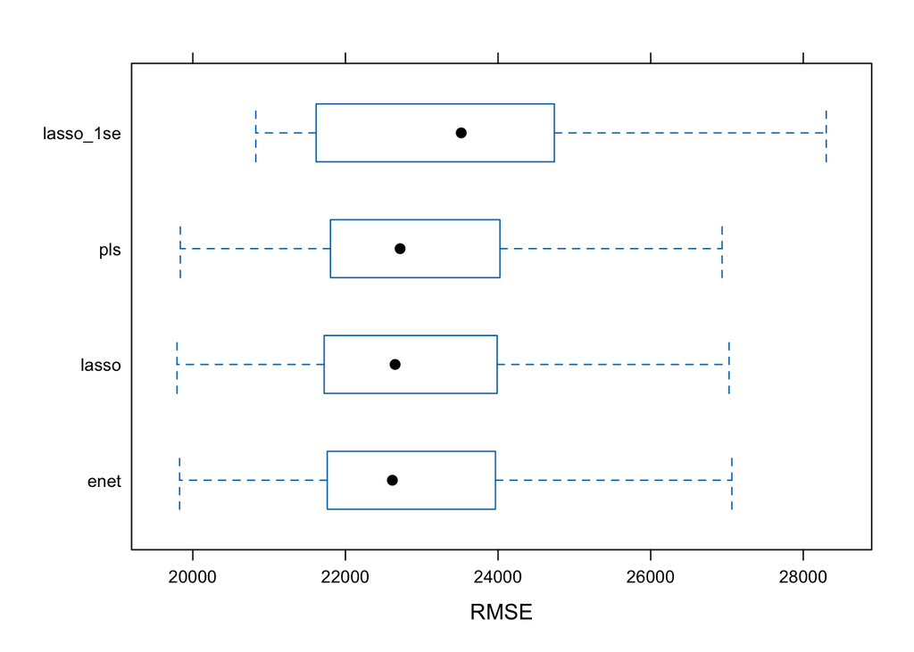

```r
bwplot(resamp, metric = "RMSE")
```

The models are fairly close, but I would opt to use the elastic net to predict the Sale Price. It is a fairly flexible model and here yields the lowest average RMSE. The lasso and PLS models are both quite close in performance as well. The lasso 1SE model has worse prediction performance, but has fewer predictors and so could be preferred on that basis. However in this case, when I am just trying to optimize predictive power, I would choose the elastic net model.

## e. Lasso using glmnet

5. If R package “caret” was used for the lasso in (a), retrain this model using R package “glmnet”, and vice versa. Compare the selected tuning parameters between the two software approaches. Should there be discrepancies in the chosen parameters, discuss potential reasons for these differences.

Fitting lasso using glmnet

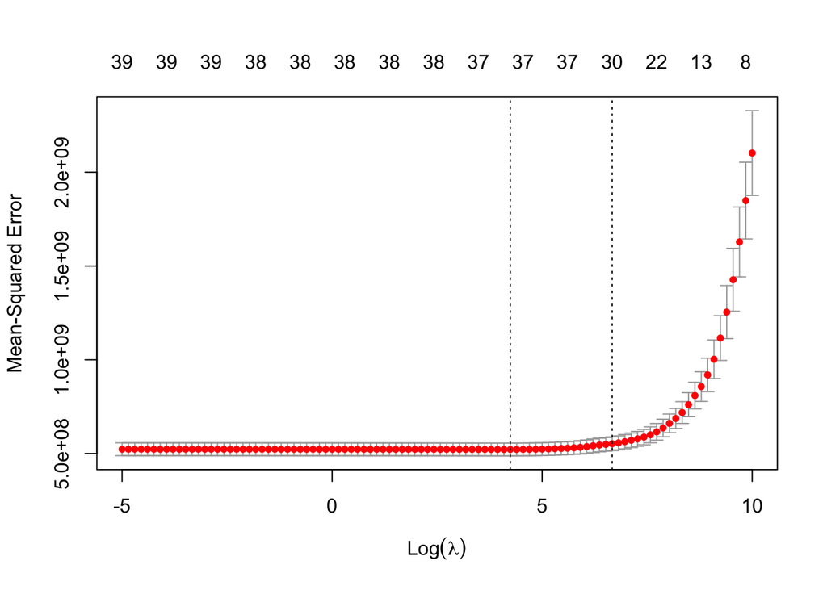

```r
x <- model.matrix(Sale_Price ~ ., training)[,-1]
y <- training$Sale_Price

set.seed(2025)

lasso.glmnet <- cv.glmnet(x, y,
                          alpha = 1,
                          lambda = exp(seq(10, -5, length = 100)))

plot(lasso.glmnet)
```

```r
lasso.glmnet$lambda.min
```

```
## [1] 69.57632
```

```r
lasso.glmnet$lambda.1se
```

```
## [1] 785.772
```

```r
# compare to the values from caret
lasso.fit$bestTune
```

|  | alpha | lambda |
| --- | --- | --- |
| 62 | 1 | 69.57632 |

```r
lasso.1se$bestTune
```

|  | alpha | lambda |
| --- | --- | --- |
| 77 | 1 | 675.2963 |

The minimum lambda value using glmnet and caret was exactly the same. The 1SE lambda value was slightly different (~785 for glmnet and ~675 for caret), but a plausible explanation for this may caret choosing the first value below the 1SE cutoff and glmnet choosing the first value above above the 1SE cutoff, rather than a more substantial estimation difference between methods.